# **Computer Assignment 3**

### SID : 810100165

### *Problem Description*

*In this project, we aim to analyze and decompose images of various flowers using clustering algorithms. Our goal is to categorize them into different clusters based on the data we have, so that after applying the clustering algorithm, they are ideally placed within their respective clusters.*

### *Goal*

*The goal of this project is to utilize clustering algorithms for the analysis and categorization of images depicting various types of flowers. By applying these algorithms, we seek to accurately group the images into clusters that reflect their intrinsic similarities, effectively organizing them based on their visual features.*

```python
import os
import cv2
import random
import numpy as np
import matplotlib.pyplot as plt
import pandas as pd
from keras.preprocessing import image
from keras.applications.vgg16 import VGG16, preprocess_input
from sklearn.cluster import KMeans, DBSCAN
from sklearn.decomposition import PCA
from sklearn.preprocessing import StandardScaler
from sklearn.metrics import silhouette_score, homogeneity_score
```

```python
folder_path = "D:/AI/A3/flower_images"
num_images_to_display = 5
eps = 100
min_samples = 2
labels_df = pd.read_csv("D:/AI/A3/flower_images/flower_labels.csv")
true_labels = labels_df['label']
```

## *Preprocess*

### *Question 1: What is feature extraction? Why is it not sufficient to merely read pixels?*

*The reason for extracting features from images using a model like VGG16 is that it allows us to capture higher-level representations of the visual content present in the images. While simply reading pixels provides raw data, it doesn't necessarily capture the semantic meaning or abstract features that might be important for tasks like image classification or clustering.* *also removing the fully connected layers of the VGG16 model and extracting features from the convolutional layers allows us to obtain a compact representation of the images that preserves important visual information while discarding irrelevant details. This feature extraction process not only reduces the dimensionality of the data, making it more manageable for subsequent analysis, but also enhances the effectiveness of clustering algorithms by providing them with meaningful and discriminative features for grouping similar images together.*

### *Question 2: techniques for feature extraction*

*Three prominent techniques for feature extraction are:*

1. **Convolutional Neural Networks (CNNs)**: *CNNs automatically learn hierarchical representations of visual features through layers like convolutional and pooling. They excel in capturing diverse features like edges, textures, and shapes and are trained on large datasets using methods like transfer learning.*
2. **Histogram of Oriented Gradients (HOG)**: *HOG focuses on gradient information by computing histograms of gradient orientations within small image cells. It's useful for tasks like pedestrian detection and object recognition.*
3. **Scale-Invariant Feature Transform (SIFT)**: *SIFT identifies key points in images and computes descriptors capturing local gradient orientations and magnitudes. It excels in scenarios with scale, rotation, and illumination variations and is widely used in image stitching and object recognition.*

*These techniques enable machines to interpret visual data effectively, facilitating tasks like image classification, object detection, and content-based image retrieval.*

### *Question 3: What preprocessing steps need to be performed on images to prepare them for entering a model?*

```python
def read_and_preprocess_images(folder_path, target_size=(224, 224), saturation_factor=1.5, contrast_factor=1):
    images = []

    for filename in os.listdir(folder_path):
        if filename.endswith(".png"):
            img_path = os.path.join(folder_path, filename)
            img = cv2.imread(img_path)

            if img is not None:

                img = cv2.convertScaleAbs(img, alpha=contrast_factor, beta=0)

                img_hsv = cv2.cvtColor(img, cv2.COLOR_BGR2HSV)

                img_hsv[:,:,1] = np.clip(img_hsv[:,:,1] * saturation_factor, 0, 255)

                lower_green = np.array([35, 50, 50])
                upper_green = np.array([90, 255, 255])
                lower_blue = np.array([90, 50, 50])
                upper_blue = np.array([130, 255, 255])
                lower_soil = np.array([0, 50, 20])
                upper_soil = np.array([30, 255, 255])
                lower_brown = np.array([10, 50, 20])
                upper_brown = np.array([20, 255, 255])

                mask_green = cv2.inRange(img_hsv, lower_green, upper_green)
                mask_blue = cv2.inRange(img_hsv, lower_blue, upper_blue)
                mask_soil = cv2.inRange(img_hsv, lower_soil, upper_soil)
                mask_brown = cv2.inRange(img_hsv, lower_brown, upper_brown)
                mask_bg = cv2.bitwise_or(mask_green, mask_blue, mask_soil, mask_brown)

                img[mask_bg != 0] = [0, 0, 0]

                img_resized = cv2.resize(img, target_size)
                images.append(img_resized)

    return np.array(images, dtype=np.uint8)

def read_and_preprocess_images_dbscan(folder_path, target_size=(224, 224)):
    images = []

    for filename in os.listdir(folder_path):
        if filename.endswith(".png"):
            img_path = os.path.join(folder_path, filename)
            img = cv2.imread(img_path)

            if img is not None:
                img_resized = cv2.resize(img, target_size)
                img_rgb = cv2.cvtColor(img_resized, cv2.COLOR_BGR2RGB)
                img_preprocessed = preprocess_input(img_rgb)
                images.append(img_preprocessed)

    return np.array(images, dtype=np.float32)
```

```python
images = read_and_preprocess_images(folder_path)
base_model = VGG16(weights='imagenet', include_top=False , pooling='avg')
features = base_model.predict(images)
```

```
7/7 ━━━━━━━━━━━━━━━━━━━━ 53s 6s/step
```

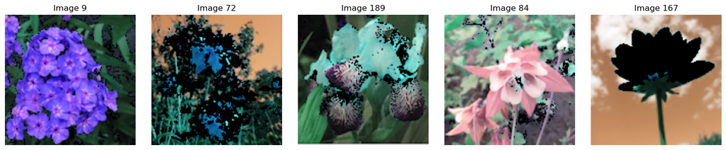

```python
plt.figure(figsize=(15, 3))
random_indices = random.sample(range(len(images)), num_images_to_display)
for i, random_index in enumerate(random_indices):
    plt.subplot(1, num_images_to_display, i + 1)
    plt.imshow(images[random_index])
    plt.title("Image " + str(random_index + 1))
    plt.axis('off')

plt.tight_layout()
plt.show()
```

## *Clustering Algorithm Implementation*

#### *Question 4: K-Means and DBSCAN methods,what are their advantages and disadvantages compared to each other?*

**K-Means:**

*K-Means algorithm works by iteratively assigning data points to the nearest cluster centroid and updating the centroids based on the mean of the data points in each cluster until convergence.*

*Advantages:*

1. *Simple and easy to implement.*
2. *Fast and efficient for large datasets.*
3. *Scalable to a large number of samples.*

*Disadvantages:*

1. *Requires predefined number of clusters (k).*
2. *Sensitive to initialization and may converge to local optima.*
3. *Assumes clusters are spherical and of similar size, which may not always be the case.*

**DBSCAN (Density-Based Spatial Clustering of Applications with Noise):**

*DBSCAN algorithm identifies clusters based on density connectivity, grouping together data points that are closely packed while separating regions of low density. It starts by selecting a point and finding its neighboring points within a specified distance epsilon (ε). If the number of neighbors exceeds a threshold, the point becomes a core point, and clusters expand from there.*

*Advantages:*

1. *Does not require predefined number of clusters.*
2. *Can handle clusters of arbitrary shape and size.*
3. *Robust to noise and outliers.*

*Disadvantages:*

1. *Sensitive to choice of distance metric and epsilon parameter.*
2. *May struggle with varying density clusters or high-dimensional data.*
3. *Computationally intensive for large datasets.*

## *K-means Algorithm:*

### *Question 5: What method have you used to find the most suitable K in the K-means method?*

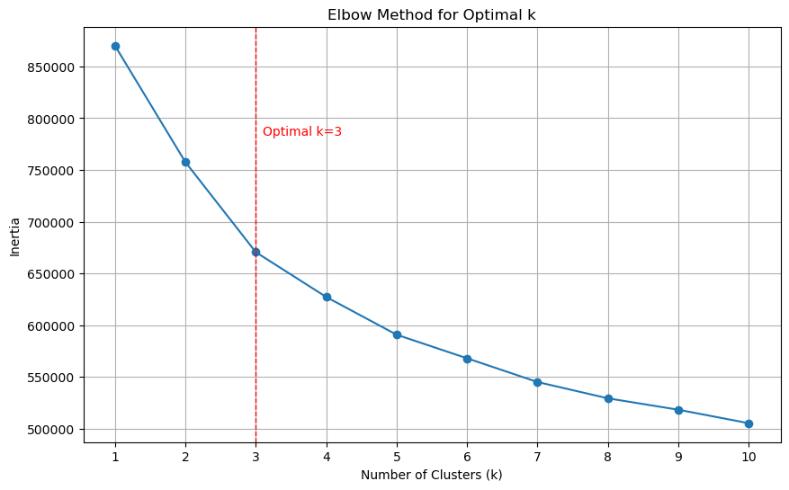

```python
inertia_values = []
for k in range(1, 11):
    kmeans = KMeans(n_clusters=k, n_init=10)
    kmeans.fit(features.reshape(features.shape[0], -1))
    inertia_values.append(kmeans.inertia_)

diff = np.diff(inertia_values)
diff_r = diff[1:] / diff[:-1]
optimal_k = np.argmin(diff_r) + 2

plt.figure(figsize=(10, 6))
plt.plot(range(1, 11), inertia_values, marker='o')
plt.xlabel('Number of Clusters (k)')
plt.ylabel('Inertia')
plt.title('Elbow Method for Optimal k')
plt.xticks(range(1, 11))
plt.grid(True)

plt.axvline(x=optimal_k, color='r', linestyle='--', linewidth=1)
plt.text(optimal_k + 0.1, max(inertia_values) * 0.9, f'Optimal k={optimal_k}', color='r')
plt.show()
```

```python
optimal_k = 10
kmeans = KMeans(n_clusters=optimal_k, n_init=10)
kmeans.fit(features.reshape(features.shape[0], -1))
cluster_labels = kmeans.labels_
```

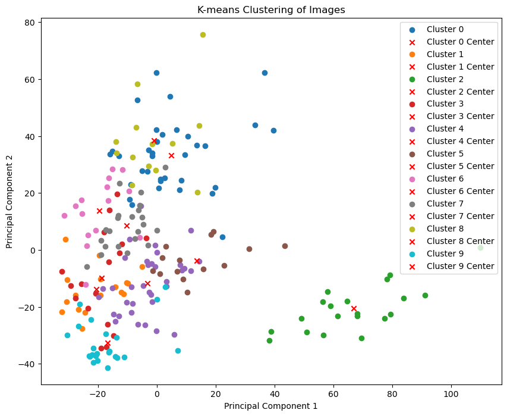

```python
pca = PCA(n_components=2)
pca_features = pca.fit_transform(features.reshape(features.shape[0], -1))
plt.figure(figsize=(10, 8))

for cluster_id in range(optimal_k):
    cluster_indices = np.where(cluster_labels == cluster_id)[0]
    plt.scatter(pca_features[cluster_indices, 0], pca_features[cluster_indices, 1], label=f'Cluster {cluster_id}')

    cluster_center = np.mean(pca_features[cluster_indices], axis=0)
    plt.scatter(cluster_center[0], cluster_center[1], marker='x', color='red', label=f'Cluster {cluster_id} Center')

plt.title('K-means Clustering of Images')
plt.xlabel('Principal Component 1')
plt.ylabel('Principal Component 2')
plt.legend()
plt.show()
```

```python
silhouette = silhouette_score(features.reshape(features.shape[0], -1), cluster_labels)
print("Silhouette Score:", silhouette)

homogeneity = homogeneity_score(true_labels, cluster_labels)
print("Homogeneity Score:", homogeneity)
```

```
Silhouette Score: 0.10387671
Homogeneity Score: 0.6090423786787867
```

## *DBSCAN Algorithm:*

```python
images = read_and_preprocess_images_dbscan(folder_path)
base_model = VGG16(weights='imagenet', include_top=False)
features = base_model.predict(images)
n_samples, height, width, channels = features.shape
features_reshaped = features.reshape((n_samples, height * width * channels))
```

```
7/7 ━━━━━━━━━━━━━━━━━━━━ 43s 6s/step
```

```python
pca = PCA(n_components=2)
features_pca = pca.fit_transform(features_reshaped)
dbscan = DBSCAN(eps=eps, min_samples=min_samples)
labels = dbscan.fit_predict(features_pca)
```

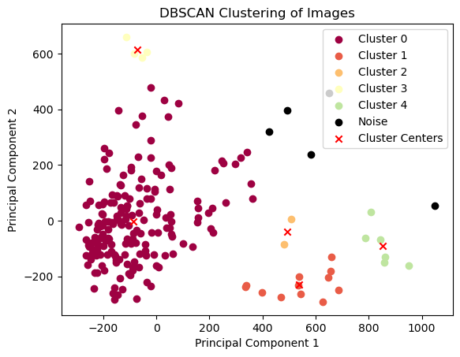

```python
cluster_names = {label: f'Cluster {label}' for label in set(labels) if label != -1}
cluster_names[-1] = 'Noise'

for label in set(labels):
    if label == -1:
        color = [0, 0, 0, 1]
    else:
        color = plt.cm.Spectral(label / len(cluster_names))

    cluster_points = features_pca[labels == label]
    plt.scatter(cluster_points[:, 0], cluster_points[:, 1], color=color, label=cluster_names[label])

cluster_centers = np.array([np.mean(features_pca[labels == label], axis=0) for label in set(labels) if label != -1])
plt.scatter(cluster_centers[:, 0], cluster_centers[:, 1], marker='x', color='red', label='Cluster Centers')

plt.title('DBSCAN Clustering of Images')
plt.xlabel('Principal Component 1')
plt.ylabel('Principal Component 2')
plt.legend()
plt.show()
```

```python
silhouette = silhouette_score(features_pca, labels)
print("Silhouette Score:", silhouette)

homogeneity = homogeneity_score(true_labels, labels)
print("Homogeneity Score:", homogeneity)
```

```
Silhouette Score: 0.47692886
Homogeneity Score: 0.1746248735661051
```

### *Question 7: What is PCA?*

*PCA, or Principal Component Analysis, is a method commonly used for reducing the dimensionality of high-dimensional data. In image clustering, where feature vectors extracted from images can have a high number of dimensions, PCA proves invaluable. It works by identifying the directions in the original feature space where the data varies the most, known as principal components. These components capture the most significant variations in the data.*

*By projecting the high-dimensional feature vectors onto a lower-dimensional subspace defined by these principal components, PCA effectively reduces the dimensionality of the data while preserving much of its inherent structure. This reduced-dimensional representation allows for easier visualization of clusters in 2D or 3D space, facilitating the interpretation of clustering results.*

## *Evaluation and Analysis*

### *Question 8: the calculation method of the silhouette and homogeneity metrics.*

***Silhouette Score***:*  
how similar an object is to its own cluster compared to other clusters  
*

- *Measures how well-separated clusters are.*
- *It takes into account both the cohesion within clusters and the separation between clusters.*
- *For each data point, the silhouette score is calculated using the following formula:*

$$s(i) = \frac{b(i) - a(i)}{\max\{a(i), b(i)\}}$$

$s(i)$ *the silhouette score for data point i.*  
$a(i)$ *(`intra cluster distance`) is the average distance from the i-th point to other points in the same cluster.*  
$b(i)$ *(`inter cluster distance`) is the smallest average distance from the ii-th point to points in a different cluster, minimized over clusters.*

- *Ranges from -1 to 1:*

*A `high` silhouette score : the object is well-matched to its own cluster and poorly matched to neighboring clusters.*  
*A `low` silhouette score : the object may be assigned to the wrong cluster.*

- *The overall silhouette score for a clustering is the* *average** of silhouette scores for all data points.*

***Homogeneity Score***:*  
It measures the extent to which each cluster contains only data points that belong to a single class.  
*

- *Measures the degree to which each cluster contains only members of a single class.*
- *Based on the concept of entropy from information theory.*
- *The homogeneity score is calculated using the following formula:*

$$H(C, K) = 1 - \frac{H(C|K)}{H(C)}$$

*where:*

$H(C,K)$ *the homogeneity score.*  
$H(C∣K)$*the conditional entropy of the class labels given the cluster assignments.*  
$H(C)$ *the entropy of the true class labels.*

- *Ranges from 0 to 1:*

*Higer score : Each cluster contains only members of a single class.*  
*Lower score : Clusters contain mixed class members.*

### *Question 9: Reporting Results of Mentioned Metrics for Each Method*

*When comparing the outputs of DBSCAN and K-means clustering algorithms, it's evident that they perform differently based on the provided evaluation metrics. DBSCAN demonstrates a higher Silhouette Score of 0.4769 compared to K-means' score of 0.1039, indicating that the data points are more tightly clustered and well-separated in the case of DBSCAN. However, in terms of Homogeneity Score, K-means outperforms DBSCAN with a score of 0.6090 compared to DBSCAN's score of 0.1746.*

### *Question 10: Suggestions for Enhancing Model Performance*

1. ***Normalization**: Ensuring that the feature vectors are properly normalized before applying clustering algorithms. Normalization aids in improving convergence and stability, particularly with distance-based algorithms like DBSCAN and K-means.*
2. ***Parameter Tuning**: Experimentation with different hyperparameters of clustering algorithms is recommended, with optimal values chosen based on validation metrics such as silhouette score or Davies–Bouldin index. Tuning parameters like epsilon for DBSCAN and the number of clusters for K-means can significantly impact clustering performance.*
3. ***Ensemble Clustering**: Combining the results of multiple clustering algorithms using ensemble methods is advisable. Ensemble clustering enhances robustness and captures various aspects of the data distribution by aggregating diverse clustering solutions.*
4. ***Distance Metric Selection**: It is important to choose appropriate distance metrics based on the characteristics of image data. For example, cosine similarity or Euclidean distance on deep feature embeddings may be more suitable for image clustering tasks compared to traditional distance metrics.*
5. ***Data Augmentation**: Augmenting the dataset with variations of existing images increases diversity and improves the generalization capability of clustering models. Techniques such as rotation, flipping, and scaling can be employed to capture different aspects of image variability.*
6. ***Domain-Specific Preprocessing**: Applying domain-specific preprocessing steps tailored to image data characteristics is crucial. Techniques such as color normalization, edge detection, or segmentation can enhance the discriminative power of clustering algorithms by extracting relevant features.*